# Meteorite landings on Earth

Shivam Chaudhary May 2021

## 1. Introduction

In this notebook I analyse and visualize the NASA Meteorite Landings dataset, which can be found [here](https://www.kaggle.com/nasa/meteorite-landings). The [Meteoritical Society](https://www.lpi.usra.edu/meteor/) collects data on meteorites that have fallen to Earth from outer space.

#### Aim of this project

This dataset offers a great opportunity to visually investigate where the chances of finding a meteorite are highest. Meteorites have fascinated me for a long time. When they enter our atmosphere as shooting stars they have often travelled for millions of kilometers. Many of the meteorites that reach our planet are very old, dating from the early days of our solar system, so they are older than the rocks from Earth.

#### About the data

This dataset includes the location, mass, composition, and fall year for over 45,000 meteorites that have struck our planet. There are a few notes on Kaggle on missing or incorrect data points in this dataset, which I'll take into account during data cleaning:

- a few entries here contain date information that was incorrectly parsed into the NASA database. As a spot check: any date that is before 860 CE or after 2016 are incorrect; these should actually be BCE years. There may be other errors and we are looking for a way to identify them.
- a few entries have latitude and longitude of 0N/0E (off the western coast of Africa, where it would be quite difficult to recover meteorites). Many of these were actually discovered in Antarctica, but exact coordinates were not given. 0N/0E locations should probably be treated as NA.

```python
!jupyter nbconvert --to html meteorite_landings.ipynb
```

```
[NbConvertApp] Converting notebook meteorite_landings.ipynb to html
[NbConvertApp] Writing 1754523 bytes to meteorite_landings.html
```

## 2. Import Packages and data

```python
# import packages
import numpy as np
import pandas as pd
%matplotlib inline
import matplotlib.pyplot as plt
import matplotlib.cm as cm
import matplotlib.patches as mpatches
import seaborn as sns
import geopandas as gpd
```

```python
# import dataset
df = pd.read_csv('meteorite-landings.csv')
df.head()
```

|  | name | id | nametype | recclass | mass | fall | year | reclat | reclong | GeoLocation |
| --- | --- | --- | --- | --- | --- | --- | --- | --- | --- | --- |
| 0 | Aachen | 1 | Valid | L5 | 21.0 | Fell | 1880.0 | 50.77500 | 6.08333 | (50.775000, 6.083330) |
| 1 | Aarhus | 2 | Valid | H6 | 720.0 | Fell | 1951.0 | 56.18333 | 10.23333 | (56.183330, 10.233330) |
| 2 | Abee | 6 | Valid | EH4 | 107000.0 | Fell | 1952.0 | 54.21667 | -113.00000 | (54.216670, -113.000000) |
| 3 | Acapulco | 10 | Valid | Acapulcoite | 1914.0 | Fell | 1976.0 | 16.88333 | -99.90000 | (16.883330, -99.900000) |
| 4 | Achiras | 370 | Valid | L6 | 780.0 | Fell | 1902.0 | -33.16667 | -64.95000 | (-33.166670, -64.950000) |

## 3. Inspecting and cleaning the data

Before I start with visualising the data, I inspect the data to check variable properties and distributions and to find and fix mistakes or unwanted datapoints.

```python
# inspect data types
#df.dtypes
df.info()
```

```
<class 'pandas.core.frame.DataFrame'>
RangeIndex: 45716 entries, 0 to 45715
Data columns (total 10 columns):
 #   Column       Non-Null Count  Dtype
---  ------       --------------  -----
 0   name         45716 non-null  object
 1   id           45716 non-null  int64
 2   nametype     45716 non-null  object
 3   recclass     45716 non-null  object
 4   mass         45585 non-null  float64
 5   fall         45716 non-null  object
 6   year         45428 non-null  float64
 7   reclat       38401 non-null  float64
 8   reclong      38401 non-null  float64
 9   GeoLocation  38401 non-null  object
dtypes: float64(4), int64(1), object(5)
memory usage: 3.5+ MB
```

```python
# Check missing values
percent_missing = df.isnull().sum() * 100 / len(df)
missing_value_df = pd.DataFrame({'percent_missing': percent_missing})
missing_value_df

# There are quite a few missing geolocations(16%).
```

|  | percent_missing |
| --- | --- |
| name | 0.000000 |
| id | 0.000000 |
| nametype | 0.000000 |
| recclass | 0.000000 |
| mass | 0.286552 |
| fall | 0.000000 |
| year | 0.629976 |
| reclat | 16.000962 |
| reclong | 16.000962 |
| GeoLocation | 16.000962 |

```python
# convert year from float to integer
df['year'] = df['year'].fillna(0).astype(int)
df.info()
```

```
<class 'pandas.core.frame.DataFrame'>
RangeIndex: 45716 entries, 0 to 45715
Data columns (total 10 columns):
 #   Column       Non-Null Count  Dtype
---  ------       --------------  -----
 0   name         45716 non-null  object
 1   id           45716 non-null  int64
 2   nametype     45716 non-null  object
 3   recclass     45716 non-null  object
 4   mass         45585 non-null  float64
 5   fall         45716 non-null  object
 6   year         45716 non-null  int32
 7   reclat       38401 non-null  float64
 8   reclong      38401 non-null  float64
 9   GeoLocation  38401 non-null  object
dtypes: float64(3), int32(1), int64(1), object(5)
memory usage: 3.3+ MB
```

```python
# inspect data with describe
df.describe()
```

|  | id | mass | year | reclat | reclong |
| --- | --- | --- | --- | --- | --- |
| count | 45716.000000 | 4.558500e+04 | 45716.000000 | 38401.000000 | 38401.000000 |
| mean | 26889.735104 | 1.327808e+04 | 1979.224495 | -39.122580 | 61.074319 |
| std | 16860.683030 | 5.749889e+05 | 159.904386 | 46.378511 | 80.647298 |
| min | 1.000000 | 0.000000e+00 | 0.000000 | -87.366670 | -165.433330 |
| 25% | 12688.750000 | 7.200000e+00 | 1987.000000 | -76.714240 | 0.000000 |
| 50% | 24261.500000 | 3.260000e+01 | 1998.000000 | -71.500000 | 35.666670 |
| 75% | 40656.750000 | 2.026000e+02 | 2003.000000 | 0.000000 | 157.166670 |
| max | 57458.000000 | 6.000000e+07 | 2501.000000 | 81.166670 | 354.473330 |

In the notes that came with the dataset it states that years before 860 and after 2016 are unreliable, and that there are several incorrect coordinates of (0,0), so those need to be filtered out.

```python
# clean data
# filter out data with year < 860 and > 2016
df2 = df[(df['year'] >= 860) & (df['year'] <= 2016)]
df2
```

|  | name | id | nametype | recclass | mass | fall | year | reclat | reclong | GeoLocation |
| --- | --- | --- | --- | --- | --- | --- | --- | --- | --- | --- |
| 0 | Aachen | 1 | Valid | L5 | 21.0 | Fell | 1880 | 50.77500 | 6.08333 | (50.775000, 6.083330) |
| 1 | Aarhus | 2 | Valid | H6 | 720.0 | Fell | 1951 | 56.18333 | 10.23333 | (56.183330, 10.233330) |
| 2 | Abee | 6 | Valid | EH4 | 107000.0 | Fell | 1952 | 54.21667 | -113.00000 | (54.216670, -113.000000) |
| 3 | Acapulco | 10 | Valid | Acapulcoite | 1914.0 | Fell | 1976 | 16.88333 | -99.90000 | (16.883330, -99.900000) |
| 4 | Achiras | 370 | Valid | L6 | 780.0 | Fell | 1902 | -33.16667 | -64.95000 | (-33.166670, -64.950000) |
| ... | ... | ... | ... | ... | ... | ... | ... | ... | ... | ... |
| 45711 | Zillah 002 | 31356 | Valid | Eucrite | 172.0 | Found | 1990 | 29.03700 | 17.01850 | (29.037000, 17.018500) |
| 45712 | Zinder | 30409 | Valid | Pallasite, ungrouped | 46.0 | Found | 1999 | 13.78333 | 8.96667 | (13.783330, 8.966670) |
| 45713 | Zlin | 30410 | Valid | H4 | 3.3 | Found | 1939 | 49.25000 | 17.66667 | (49.250000, 17.666670) |
| 45714 | Zubkovsky | 31357 | Valid | L6 | 2167.0 | Found | 2003 | 49.78917 | 41.50460 | (49.789170, 41.504600) |
| 45715 | Zulu Queen | 30414 | Valid | L3.7 | 200.0 | Found | 1976 | 33.98333 | -115.68333 | (33.983330, -115.683330) |

45424 rows × 10 columns

```python
# clean data
# filter out data with 0,0 coordinates
df3 = df2.loc[(df2['reclat'] != 0) & (df2['reclong'] != 0)]
```

- **lets replace mass null values with their mean values**

```python
mean_mass= round(df3['mass'].mean(),2)
mean_mass
```

```
15442.83
```

```python
df3['mass']=np.where(np.isnan(df3['mass']),mean_mass,df3['mass'])
df3['mass']
```

```
0            21.0
1           720.0
2        107000.0
3          1914.0
4           780.0
           ...
45711       172.0
45712        46.0
45713         3.3
45714      2167.0
45715       200.0
Name: mass, Length: 39015, dtype: float64
```

```python
df3.info()
```

```
<class 'pandas.core.frame.DataFrame'>
Int64Index: 39015 entries, 0 to 45715
Data columns (total 10 columns):
 #   Column       Non-Null Count  Dtype
---  ------       --------------  -----
 0   name         39015 non-null  object
 1   id           39015 non-null  int64
 2   nametype     39015 non-null  object
 3   recclass     39015 non-null  object
 4   mass         39015 non-null  float64
 5   fall         39015 non-null  object
 6   year         39015 non-null  int32
 7   reclat       31813 non-null  float64
 8   reclong      31813 non-null  float64
 9   GeoLocation  31813 non-null  object
dtypes: float64(3), int32(1), int64(1), object(5)
memory usage: 3.1+ MB
```

```python
# inspecting properties and distribution of variables

# types of recclass
meteor_types = pd.DataFrame(df3['recclass'].value_counts())
meteor_types.tail(50)
```

|  | recclass |
| --- | --- |
| H/L3.6 | 1 |
| CO3.7 | 1 |
| L/LL6-an | 1 |
| Iron? | 1 |
| H3.8-5 | 1 |
| R3.8-5 | 1 |
| L3.9/4 | 1 |
| H/L3.9 | 1 |
| L/LL3.10 | 1 |
| L~3 | 1 |
| H(L)3-an | 1 |
| L-melt breccia | 1 |
| CV2 | 1 |
| L3.2-3.5 | 1 |
| EL7 | 1 |
| CH/CBb | 1 |
| H/L~4 | 1 |
| LL3.7-6 | 1 |
| H3.7/3.8 | 1 |
| L3.7/3.8 | 1 |
| L3.5-3.9 | 1 |
| L3.3-3.5 | 1 |
| LL3/4 | 1 |
| L3.0-3.7 | 1 |
| K | 1 |
| Acapulcoite/lodranite | 1 |
| L3.10 | 1 |
| L/LL4/5 | 1 |
| L3.8-an | 1 |
| C5/6-ung | 1 |
| H3.8-4 | 1 |
| H6 | 1 |
| H3 | 1 |
| CR1 | 1 |
| H3.4/3.5 | 1 |
| Mesosiderite? | 1 |
| L3.5-3.7 | 1 |
| Iron, IIAB-an | 1 |
| L3.3-3.7 | 1 |
| L3.2-3.6 | 1 |
| L3.3-3.6 | 1 |
| C2 | 1 |
| C4/5 | 1 |
| L3.5-5 | 1 |
| L/LL(?)3 | 1 |
| H4(?) | 1 |
| Relict iron | 1 |
| EL4/5 | 1 |
| L5-7 | 1 |
| L/LL | 1 |

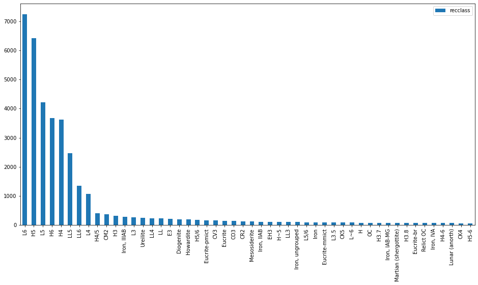

```python
# Plotting the counts of the meteor types we can see that are 8 most common types,
# after which there are many types with relatively low numbers

plt.rcParams['figure.figsize'] = [16,8,]
meteor_types.head(50).plot.bar()
```

#### Types of meteorite

The most common types of meteorites in the data are: L6, H5, L5, H6, H4, LL5, LL6, L4

These all fall in the category 'ordinary chondrites'

From wikipedia: A chondrite /ˈkɒndraɪt/ is a stony (non-metallic) meteorite that has not been modified, by either melting or differentiation of the parent body. They are formed when various types of dust and small grains in the early Solar System accreted to form primitive asteroids. Some such bodies that are captured in the planet’s gravity well become the most common type of meteorite by (whether quickly, or after many orbits) arriving on a trajectory toward the Earth’s surface. Estimates for their contribution to the total meteorite population vary between 85.7% and 86.2%.

```python
# inspecting properties and distribution of variables

# column 'fall'

df3['fall'].value_counts()

# There are many more 'found' meteorites than 'fell' meteorites
```

```
Found    37910
Fell      1105
Name: fall, dtype: int64
```

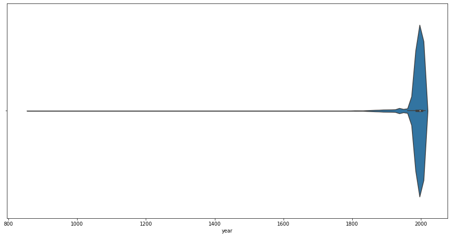

```python
sns.violinplot(x = 'year', data = df3)

# the vast majority of observations are between 1900 and 2016, which is to be expected
```

## 4. Plotting the meteorites on a world map

There are many ways to visualise the meteorite data on maps, but as a start I'll plot all the meteorites as points on a world map.

- convert the data into geospatial data so it can be spatially plotted with a package such as geopandas
- get data to plot a world map
- plot the world map data and the meteorite data in two layers

```python
from geopy.geocoders import Nominatim
```

```python
df3
```

|  | name | id | nametype | recclass | mass | fall | year | reclat | reclong | GeoLocation |
| --- | --- | --- | --- | --- | --- | --- | --- | --- | --- | --- |
| 0 | Aachen | 1 | Valid | L5 | 21.0 | Fell | 1880 | 50.77500 | 6.08333 | (50.775000, 6.083330) |
| 1 | Aarhus | 2 | Valid | H6 | 720.0 | Fell | 1951 | 56.18333 | 10.23333 | (56.183330, 10.233330) |
| 2 | Abee | 6 | Valid | EH4 | 107000.0 | Fell | 1952 | 54.21667 | -113.00000 | (54.216670, -113.000000) |
| 3 | Acapulco | 10 | Valid | Acapulcoite | 1914.0 | Fell | 1976 | 16.88333 | -99.90000 | (16.883330, -99.900000) |
| 4 | Achiras | 370 | Valid | L6 | 780.0 | Fell | 1902 | -33.16667 | -64.95000 | (-33.166670, -64.950000) |
| ... | ... | ... | ... | ... | ... | ... | ... | ... | ... | ... |
| 45711 | Zillah 002 | 31356 | Valid | Eucrite | 172.0 | Found | 1990 | 29.03700 | 17.01850 | (29.037000, 17.018500) |
| 45712 | Zinder | 30409 | Valid | Pallasite, ungrouped | 46.0 | Found | 1999 | 13.78333 | 8.96667 | (13.783330, 8.966670) |
| 45713 | Zlin | 30410 | Valid | H4 | 3.3 | Found | 1939 | 49.25000 | 17.66667 | (49.250000, 17.666670) |
| 45714 | Zubkovsky | 31357 | Valid | L6 | 2167.0 | Found | 2003 | 49.78917 | 41.50460 | (49.789170, 41.504600) |
| 45715 | Zulu Queen | 30414 | Valid | L3.7 | 200.0 | Found | 1976 | 33.98333 | -115.68333 | (33.983330, -115.683330) |

39015 rows × 10 columns

```python
# create geodataframe, with geometry column from long, lat columns

gdf = gpd.GeoDataFrame(df3, geometry = gpd.points_from_xy(df3['reclong'], df3['reclat']))
gdf.head()
```

|  | name | id | nametype | recclass | mass | fall | year | reclat | reclong | GeoLocation | geometry |
| --- | --- | --- | --- | --- | --- | --- | --- | --- | --- | --- | --- |
| 0 | Aachen | 1 | Valid | L5 | 21.0 | Fell | 1880 | 50.77500 | 6.08333 | (50.775000, 6.083330) | POINT (6.08333 50.77500) |
| 1 | Aarhus | 2 | Valid | H6 | 720.0 | Fell | 1951 | 56.18333 | 10.23333 | (56.183330, 10.233330) | POINT (10.23333 56.18333) |
| 2 | Abee | 6 | Valid | EH4 | 107000.0 | Fell | 1952 | 54.21667 | -113.00000 | (54.216670, -113.000000) | POINT (-113.00000 54.21667) |
| 3 | Acapulco | 10 | Valid | Acapulcoite | 1914.0 | Fell | 1976 | 16.88333 | -99.90000 | (16.883330, -99.900000) | POINT (-99.90000 16.88333) |
| 4 | Achiras | 370 | Valid | L6 | 780.0 | Fell | 1902 | -33.16667 | -64.95000 | (-33.166670, -64.950000) | POINT (-64.95000 -33.16667) |

```python
#check whether the geometry column is the right datatype. It should be a geopandas geoseries

type(gdf.geometry)
```

```
geopandas.geoseries.GeoSeries
```

```python
# import world map geodataframe. The lowres worldmap dataset from Natural Earth can be imported directly from geopandas

world = gpd.read_file(gpd.datasets.get_path('naturalearth_lowres'))
world.rename(columns = {'name': 'country'}, inplace = True)
world.head()
```

|  | pop_est | continent | country | iso_a3 | gdp_md_est | geometry |
| --- | --- | --- | --- | --- | --- | --- |
| 0 | 920938 | Oceania | Fiji | FJI | 8374.0 | MULTIPOLYGON (((180.00000 -16.06713, 180.00000... |
| 1 | 53950935 | Africa | Tanzania | TZA | 150600.0 | POLYGON ((33.90371 -0.95000, 34.07262 -1.05982... |
| 2 | 603253 | Africa | W. Sahara | ESH | 906.5 | POLYGON ((-8.66559 27.65643, -8.66512 27.58948... |
| 3 | 35623680 | North America | Canada | CAN | 1674000.0 | MULTIPOLYGON (((-122.84000 49.00000, -122.9742... |
| 4 | 326625791 | North America | United States of America | USA | 18560000.0 | MULTIPOLYGON (((-122.84000 49.00000, -120.0000... |

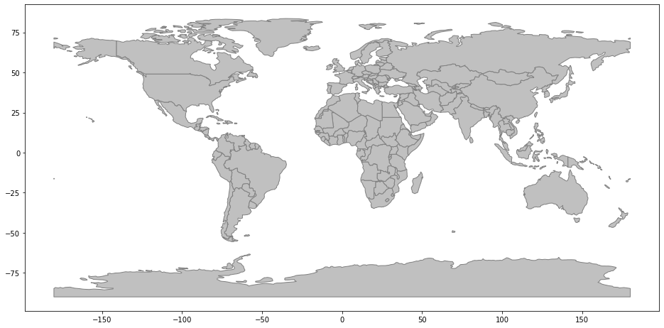

```python
# plot world map with country borders

plt.rcParams['figure.figsize'] = [16,8]
world.plot(facecolor = 'silver', edgecolor = 'grey');
```

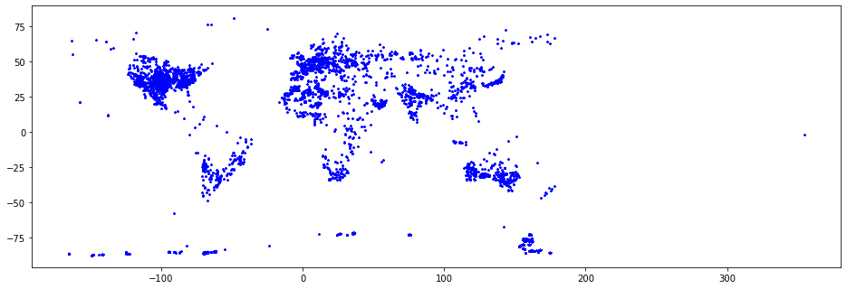

```python
# Plot layer of meteorites

gdf.plot(marker='*', color='blue', markersize=5);
```

```python
# There's a weird point that must be a mistake. longitude is larger than 300
# find entry in df

gdf.loc[(df3['reclong'] > 300)]
```

|  | name | id | nametype | recclass | mass | fall | year | reclat | reclong | GeoLocation | geometry |
| --- | --- | --- | --- | --- | --- | --- | --- | --- | --- | --- | --- |
| 22946 | Meridiani Planum | 32789 | Valid | Iron, IAB complex | 15442.83 | Found | 2005 | -1.94617 | 354.47333 | (-1.946170, 354.473330) | POINT (354.473 -1.946) |

```python
# remove entry

gdf = gdf.drop([22946], axis=0)
```

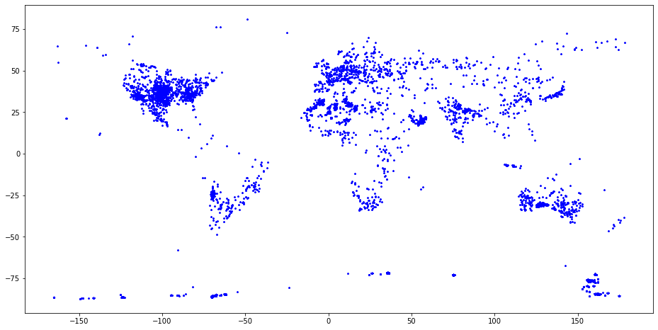

```python
# Plot meteorites again to check whether the point is gone

gdf.plot(marker='*', color='blue', markersize=5);
```

```python
# Before combining maps, ensure they share a common CRS (coordinate reference system) so that they will spatially align

# first assign a CRS to the gdf (a common one is WGS84 latitude-longitude coordinate system)

gdf.crs = "EPSG:4326"

# then, align crs to world crs

gdf = gdf.to_crs(world.crs)
```

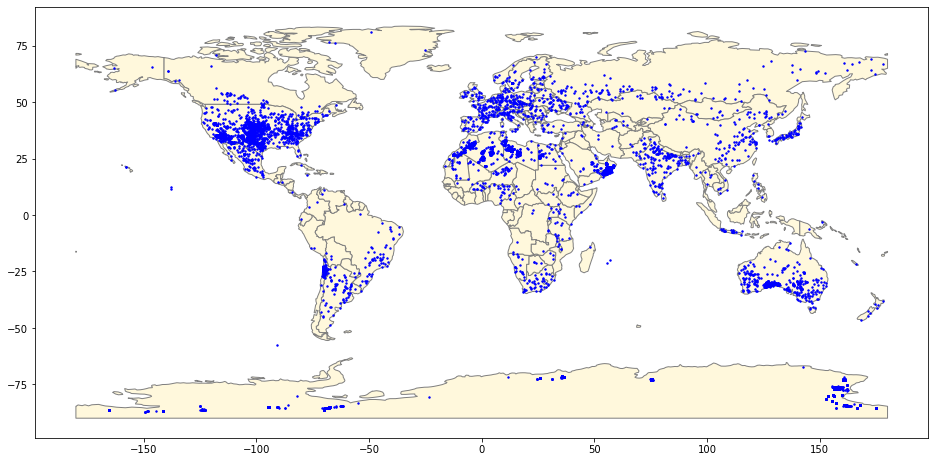

```python
# Plotting the world map data and the meteorite points in two layers:

base = world.plot(color='cornsilk', edgecolor='grey')
gdf.plot(ax=base, marker='o', color='blue', markersize=2);
```

#### Insights from this map

Although this figure gives a nice overview of overall densities, there is also a lot of overlap between data points (because there are so many). As a next step I'll visualise the number of meteorites per country.

## 5. Creating a choropleth map of meteorite numbers by country

To get a more detailed insight into the spatial distribution of found meteorites, I will create a choropleth map of numbers of meteorites per country. A choropleth map is a type of thematic map in which areas are shaded or patterned in proportion to a statistical variable that represents an aggregate summary of a geographic characteristic within each area, such as population density or per-capita income.

There are several steps involved in creating this map:

**1. Create a dataframe with the total number of meteorites per country.**  
For this we first need to assign country names to the meteorite data. The dataset as it comes doesn't have country information. So based on the long, lat coordinates of the meteorites we have to group the data points corresponding to the country polygon shapes in the worldmap dataset. We can do this in geopandas with a spatial join.

**2. Create a new dataframe combining the worldmap data and the meteorite counts per country.**  
Doing this we'll end up with a lot of missing data for the counts per country. We can fill these in with zeroes because for these countries zero meteorites were found.

**3. Create the choropleth map in geopandas.**  
This will require some tweaking of the colour-representation of the meteorite counts as this data is highly skewed as we will see.

```python
# Create df total meteorites per country
# first, spatial join meteorite gdf and world gdf to assign countries to meteorite coordinates

gdf_countries = gpd.sjoin(world, gdf, how="right", op="contains")
gdf_countries.head()
```

|  | index_left | pop_est | continent | country | iso_a3 | gdp_md_est | name | id | nametype | recclass | mass | fall | year | reclat | reclong | GeoLocation | geometry |
| --- | --- | --- | --- | --- | --- | --- | --- | --- | --- | --- | --- | --- | --- | --- | --- | --- | --- |
| 0 | 129.0 | 11491346.0 | Europe | Belgium | BEL | 508600.0 | Aachen | 1 | Valid | L5 | 21.0 | Fell | 1880 | 50.77500 | 6.08333 | (50.775000, 6.083330) | POINT (6.08333 50.77500) |
| 1 | 142.0 | 5605948.0 | Europe | Denmark | DNK | 264800.0 | Aarhus | 2 | Valid | H6 | 720.0 | Fell | 1951 | 56.18333 | 10.23333 | (56.183330, 10.233330) | POINT (10.23333 56.18333) |
| 2 | 3.0 | 35623680.0 | North America | Canada | CAN | 1674000.0 | Abee | 6 | Valid | EH4 | 107000.0 | Fell | 1952 | 54.21667 | -113.00000 | (54.216670, -113.000000) | POINT (-113.00000 54.21667) |
| 3 | 27.0 | 124574795.0 | North America | Mexico | MEX | 2307000.0 | Acapulco | 10 | Valid | Acapulcoite | 1914.0 | Fell | 1976 | 16.88333 | -99.90000 | (16.883330, -99.900000) | POINT (-99.90000 16.88333) |
| 4 | 9.0 | 44293293.0 | South America | Argentina | ARG | 879400.0 | Achiras | 370 | Valid | L6 | 780.0 | Fell | 1902 | -33.16667 | -64.95000 | (-33.166670, -64.950000) | POINT (-64.95000 -33.16667) |

```python
# check shape

gdf_countries.shape
```

```
(39014, 17)
```

```python
# aggregate total number of meteorites per country

by_country = gdf_countries.groupby('country')[['id']].count()
by_country = by_country.reset_index()
by_country.rename(columns = {'id': 'meteorite_count'}, inplace = True)
by_country.iloc[40:45]
```

|  | country | meteorite_count |
| --- | --- | --- |
| 40 | Greenland | 3 |
| 41 | Guatemala | 1 |
| 42 | Honduras | 1 |
| 43 | Hungary | 7 |
| 44 | India | 132 |

```python
# make new df with all country data, even if no meteorite data is available (otherwise there will be gaps in the worldmap)

countries_count = pd.merge(world, by_country, on = 'country', how = 'left')
countries_count.head()
```

|  | pop_est | continent | country | iso_a3 | gdp_md_est | geometry | meteorite_count |
| --- | --- | --- | --- | --- | --- | --- | --- |
| 0 | 920938 | Oceania | Fiji | FJI | 8374.0 | MULTIPOLYGON (((180.00000 -16.06713, 180.00000... | NaN |
| 1 | 53950935 | Africa | Tanzania | TZA | 150600.0 | POLYGON ((33.90371 -0.95000, 34.07262 -1.05982... | 9.0 |
| 2 | 603253 | Africa | W. Sahara | ESH | 906.5 | POLYGON ((-8.66559 27.65643, -8.66512 27.58948... | 6.0 |
| 3 | 35623680 | North America | Canada | CAN | 1674000.0 | MULTIPOLYGON (((-122.84000 49.00000, -122.9742... | 60.0 |
| 4 | 326625791 | North America | United States of America | USA | 18560000.0 | MULTIPOLYGON (((-122.84000 49.00000, -120.0000... | 1653.0 |

```python
# Fill NaN values for meteorite count with zeroes

countries_count.fillna(value = 0, inplace = True)
countries_count.head()
```

|  | pop_est | continent | country | iso_a3 | gdp_md_est | geometry | meteorite_count |
| --- | --- | --- | --- | --- | --- | --- | --- |
| 0 | 920938 | Oceania | Fiji | FJI | 8374.0 | MULTIPOLYGON (((180.00000 -16.06713, 180.00000... | 0.0 |
| 1 | 53950935 | Africa | Tanzania | TZA | 150600.0 | POLYGON ((33.90371 -0.95000, 34.07262 -1.05982... | 9.0 |
| 2 | 603253 | Africa | W. Sahara | ESH | 906.5 | POLYGON ((-8.66559 27.65643, -8.66512 27.58948... | 6.0 |
| 3 | 35623680 | North America | Canada | CAN | 1674000.0 | MULTIPOLYGON (((-122.84000 49.00000, -122.9742... | 60.0 |
| 4 | 326625791 | North America | United States of America | USA | 18560000.0 | MULTIPOLYGON (((-122.84000 49.00000, -120.0000... | 1653.0 |

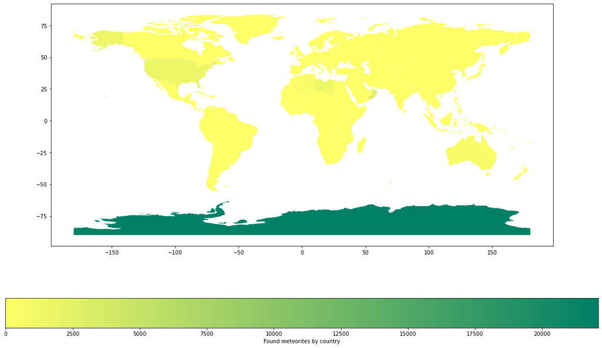

```python
# make choropleth map with number of meteorites per country indicated with colours
# see: https://geopandas.org/mapping.html
# include legend

plt.rcParams['figure.figsize'] = [20,12]
fig, ax = plt.subplots(1, 1)
countries_count.plot(column='meteorite_count', ax=ax, legend=True, cmap='summer_r',legend_kwds={'label': "Found meteorites by country",'orientation': "horizontal"})
```

#### Insights from this map

This map shows very clearly that by far the most meteorites have been found in Antarctica. In comparison the numbers for the other countries are much lower, which makes the colour contrasts for the rest of the countries very small.

According to the data, 22099 meteorites were found in Antarctica, more or less half of the data points. This is because several expeditions specifically dedicated to finding meteorites were organised in recent years. Meteorites are relatively easy to find in Antarctica because they fall on the ice sheet and are clearly visible.

To create more contrast between the countries, we can tweak the colour scaling with the scheme option.

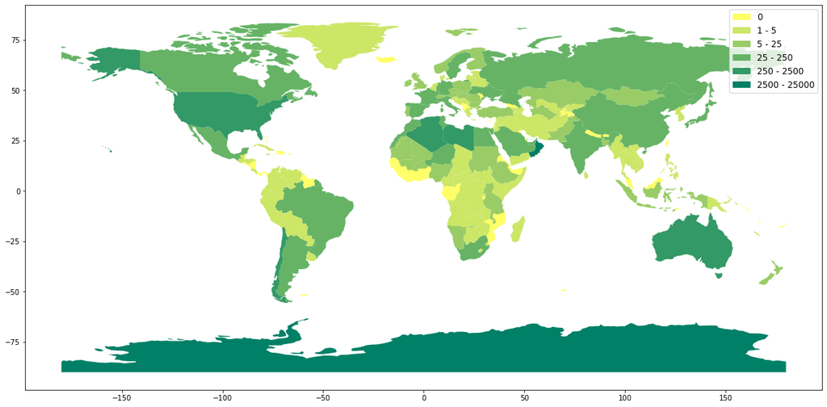

```python
# plot choropleth map with scheme option with user defined settings

plt.rcParams['figure.figsize'] = [20, 10]
fig, ax = plt.subplots(1, 1)

countries_count.plot(column='meteorite_count', legend=True, ax = ax, cmap='summer_r', scheme='user_defined', classification_kwds = {'bins':[0, 5, 25, 250, 2500, 25000]})

cmap = cm.get_cmap('summer_r')
patch1 = mpatches.Patch(color=cmap(0.0), label = '0')
patch2 = mpatches.Patch(color=cmap(0.2), label = '1 - 5')
patch3 = mpatches.Patch(color=cmap(0.4), label = '5 - 25')
patch4 = mpatches.Patch(color=cmap(0.6), label = '25 - 250')
patch5 = mpatches.Patch(color=cmap(0.8), label = '250 - 2500')
patch6 = mpatches.Patch(color=cmap(1.0), label = '2500 - 25000')

plt.legend(handles = [patch1, patch2, patch3, patch4, patch5, patch6], prop = {'size':12},loc = 0)

plt.show()
```

#### Insights from this map

Apart from Antarctica, other countries where a lot of meteorites were found are: the US, Australia, Chile, Morocco, Algeria, Libia and Oman.

These patterns are most likely explained by two main factors: national interest in meteorites (US, where the Meteoritical Society is based), and landscape/ ecotype. Apart from the US and Antartica, the other counties mentioned above all largely consist of desert, where meteorites are easier to find.

Let's now have a look at the map without Antarctica.

```python
# create new dataframe without Antarctica data

countries_count2 = countries_count[countries_count['continent'] != 'Antarctica']
```

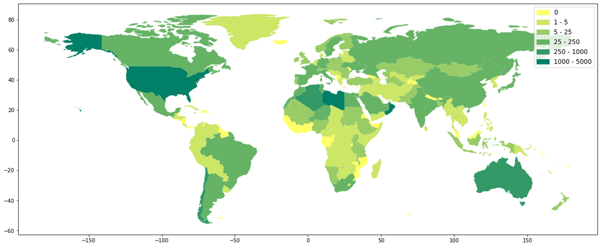

```python
# plot the map

plt.rcParams['figure.figsize'] = [20, 10]
fig, ax = plt.subplots(1, 1)

countries_count2.plot(column='meteorite_count', legend=True, ax = ax, cmap='summer_r', scheme='user_defined', classification_kwds = {'bins':[0, 5, 25, 250, 1000, 5000]})

cmap = cm.get_cmap('summer_r')
patch1 = mpatches.Patch(color=cmap(0.0), label = '0')
patch2 = mpatches.Patch(color=cmap(0.2), label = '1 - 5')
patch3 = mpatches.Patch(color=cmap(0.4), label = '5 - 25')
patch4 = mpatches.Patch(color=cmap(0.6), label = '25 - 250')
patch5 = mpatches.Patch(color=cmap(0.8), label = '250 - 1000')
patch6 = mpatches.Patch(color=cmap(1.0), label = '1000 - 5000')

plt.legend(handles = [patch1, patch2, patch3, patch4, patch5, patch6], prop = {'size':12})

plt.show()
```

#### Insights from this map

Removing Antarctica gives a more precise view of the differences between countries. According to this map the most meteorites were found in the US, Libya and Oman. Other countries that score high are Australia, Algeria and Chile.

Let's zoom in on India.

## 6. Zooming in on one country: India

To investigate the meteorite situation in India, we can plot the meteorite points on the map of India. To do this, we need to plot the country polygon shape data as a base map and overlay the meteorite points. We'll start by importing a higher resolution worldmap using this [data folder](https://www.naturalearthdata.com/http//www.naturalearthdata.com/download/50m/cultural/50m_cultural.zip) that I obtained from [Natural Earth Data](https://www.naturalearthdata.com/) and selecting the Indian shape data. After that we can select the data for India from the gdf_countries geodataframe that we created in an earlier step.

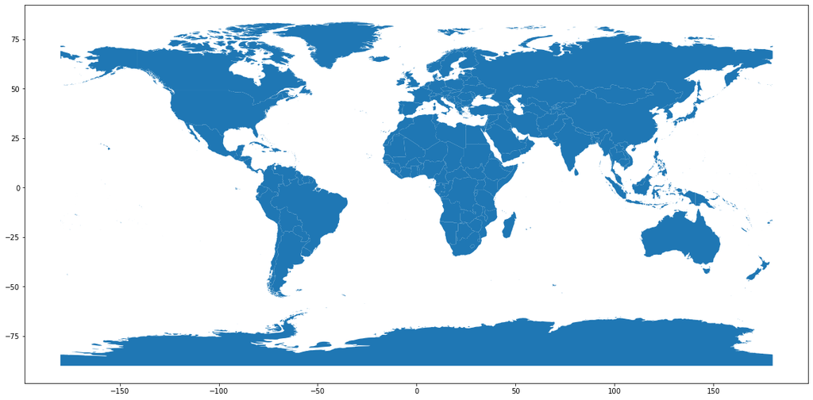

```python
# import high-res worldmap data

world2 = gpd.read_file('./data/ne_50m_admin_0_countries.shp')
world2.plot()
```

```python
# inspect worlddata gdf

world2.head()
```

|  | featurecla | scalerank | LABELRANK | SOVEREIGNT | SOV_A3 | ADM0_DIF | LEVEL | TYPE | ADMIN | ADM0_A3 | ... | NAME_KO | NAME_NL | NAME_PL | NAME_PT | NAME_RU | NAME_SV | NAME_TR | NAME_VI | NAME_ZH | geometry |
| --- | --- | --- | --- | --- | --- | --- | --- | --- | --- | --- | --- | --- | --- | --- | --- | --- | --- | --- | --- | --- | --- |
| 0 | Admin-0 country | 1 | 3 | Zimbabwe | ZWE | 0 | 2 | Sovereign country | Zimbabwe | ZWE | ... | 짐바브웨 | Zimbabwe | Zimbabwe | Zimbábue | Зимбабве | Zimbabwe | Zimbabve | Zimbabwe | 辛巴威 | POLYGON ((31.28789 -22.40205, 31.19727 -22.344... |
| 1 | Admin-0 country | 1 | 3 | Zambia | ZMB | 0 | 2 | Sovereign country | Zambia | ZMB | ... | 잠비아 | Zambia | Zambia | Zâmbia | Замбия | Zambia | Zambiya | Zambia | 赞比亚 | POLYGON ((30.39609 -15.64307, 30.25068 -15.643... |
| 2 | Admin-0 country | 1 | 3 | Yemen | YEM | 0 | 2 | Sovereign country | Yemen | YEM | ... | 예멘 | Jemen | Jemen | Iémen | Йемен | Jemen | Yemen | Yemen | 也门 | MULTIPOLYGON (((53.08564 16.64839, 52.58145 16... |
| 3 | Admin-0 country | 3 | 2 | Vietnam | VNM | 0 | 2 | Sovereign country | Vietnam | VNM | ... | 베트남 | Vietnam | Wietnam | Vietname | Вьетнам | Vietnam | Vietnam | Việt Nam | 越南 | MULTIPOLYGON (((104.06396 10.39082, 104.08301 ... |
| 4 | Admin-0 country | 5 | 3 | Venezuela | VEN | 0 | 2 | Sovereign country | Venezuela | VEN | ... | 베네수엘라 | Venezuela | Wenezuela | Venezuela | Венесуэла | Venezuela | Venezuela | Venezuela | 委內瑞拉 | MULTIPOLYGON (((-60.82119 9.13838, -60.94141 9... |

5 rows × 95 columns

```python
# select map shape INDIA

india = world2.loc[world2['SOVEREIGNT'] == 'India']
india
```

|  | featurecla | scalerank | LABELRANK | SOVEREIGNT | SOV_A3 | ADM0_DIF | LEVEL | TYPE | ADMIN | ADM0_A3 | ... | NAME_KO | NAME_NL | NAME_PL | NAME_PT | NAME_RU | NAME_SV | NAME_TR | NAME_VI | NAME_ZH | geometry |
| --- | --- | --- | --- | --- | --- | --- | --- | --- | --- | --- | --- | --- | --- | --- | --- | --- | --- | --- | --- | --- | --- |
| 144 | Admin-0 country | 1 | 2 | India | IND | 0 | 2 | Sovereign country | India | IND | ... | 인도 | India | Indie | Índia | Индия | Indien | Hindistan | Ấn Độ | 印度 | MULTIPOLYGON (((68.16504 23.85732, 68.23418 23... |

1 rows × 95 columns

```python
# select meteorite data for india

india_count = gdf_countries.loc[gdf_countries['country'] == 'India']
india_count.head()
```

|  | index_left | pop_est | continent | country | iso_a3 | gdp_md_est | name | id | nametype | recclass | mass | fall | year | reclat | reclong | GeoLocation | geometry |
| --- | --- | --- | --- | --- | --- | --- | --- | --- | --- | --- | --- | --- | --- | --- | --- | --- | --- |
| 14 | 98.0 | 1.281936e+09 | Asia | India | IND | 8721000.0 | Akbarpur | 427 | Valid | H4 | 1800.0 | Fell | 1838 | 29.71667 | 77.95000 | (29.716670, 77.950000) | POINT (77.95000 29.71667) |
| 32 | 98.0 | 1.281936e+09 | Asia | India | IND | 8721000.0 | Ambapur Nagla | 2290 | Valid | H5 | 6400.0 | Fell | 1895 | 27.66667 | 78.25000 | (27.666670, 78.250000) | POINT (78.25000 27.66667) |
| 33 | 98.0 | 1.281936e+09 | Asia | India | IND | 8721000.0 | Andhara | 2294 | Valid | Stone-uncl | 2700.0 | Fell | 1880 | 26.58333 | 85.56667 | (26.583330, 85.566670) | POINT (85.56667 26.58333) |
| 36 | 98.0 | 1.281936e+09 | Asia | India | IND | 8721000.0 | Andura | 2298 | Valid | H6 | 17900.0 | Fell | 1939 | 20.88333 | 76.86667 | (20.883330, 76.866670) | POINT (76.86667 20.88333) |
| 52 | 98.0 | 1.281936e+09 | Asia | India | IND | 8721000.0 | Atarra | 4883 | Valid | L4 | 1280.0 | Fell | 1920 | 25.25417 | 80.62500 | (25.254170, 80.625000) | POINT (80.62500 25.25417) |

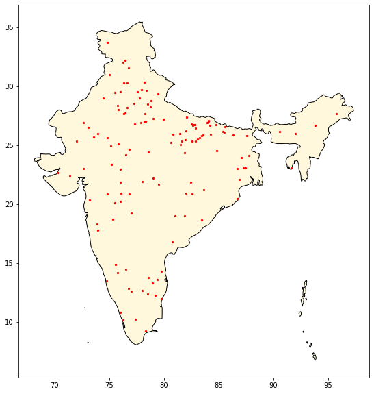

```python
# plot two layer map for India

base = india.plot(color='cornsilk', edgecolor='black')
india_count.plot(ax=base, marker='o', color='red', markersize=5);
```

#### Insights from this map

This map shows that there are several clear clusters of meterorite finds. They could be cause by expeditions, or perhaps by larger meteorite impacts.

Let's look at meteorite types in more detail.

```python
# counting the top 10 meteorite types in the india data

india_top10 = pd.DataFrame(india_count['recclass'].value_counts().head(10))
india_top10 = india_top10.reset_index()
india_top10
```

|  | index | recclass |
| --- | --- | --- |
| 0 | L6 | 24 |
| 1 | H6 | 20 |
| 2 | H5 | 14 |
| 3 | L5 | 10 |
| 4 | LL6 | 6 |
| 5 | Stone-uncl | 4 |
| 6 | H4 | 3 |
| 7 | Eucrite-mmict | 3 |
| 8 | CM2 | 3 |
| 9 | Ureilite | 3 |

### Let's look at the distribution of the top 10 meteorites in india.

```python
# Select meteorite data for india, top 10 most common meteorites

india_count10 = india_count.loc[india_count['recclass'].isin(india_top10['index'])]
india_count10.head()
```

|  | index_left | pop_est | continent | country | iso_a3 | gdp_md_est | name | id | nametype | recclass | mass | fall | year | reclat | reclong | GeoLocation | geometry |
| --- | --- | --- | --- | --- | --- | --- | --- | --- | --- | --- | --- | --- | --- | --- | --- | --- | --- |
| 14 | 98.0 | 1.281936e+09 | Asia | India | IND | 8721000.0 | Akbarpur | 427 | Valid | H4 | 1800.0 | Fell | 1838 | 29.71667 | 77.95000 | (29.716670, 77.950000) | POINT (77.95000 29.71667) |
| 32 | 98.0 | 1.281936e+09 | Asia | India | IND | 8721000.0 | Ambapur Nagla | 2290 | Valid | H5 | 6400.0 | Fell | 1895 | 27.66667 | 78.25000 | (27.666670, 78.250000) | POINT (78.25000 27.66667) |
| 33 | 98.0 | 1.281936e+09 | Asia | India | IND | 8721000.0 | Andhara | 2294 | Valid | Stone-uncl | 2700.0 | Fell | 1880 | 26.58333 | 85.56667 | (26.583330, 85.566670) | POINT (85.56667 26.58333) |
| 36 | 98.0 | 1.281936e+09 | Asia | India | IND | 8721000.0 | Andura | 2298 | Valid | H6 | 17900.0 | Fell | 1939 | 20.88333 | 76.86667 | (20.883330, 76.866670) | POINT (76.86667 20.88333) |
| 72 | 98.0 | 1.281936e+09 | Asia | India | IND | 8721000.0 | Bansur | 4936 | Valid | L6 | 15000.0 | Fell | 1892 | 27.70000 | 76.33333 | (27.700000, 76.333330) | POINT (76.33333 27.70000) |

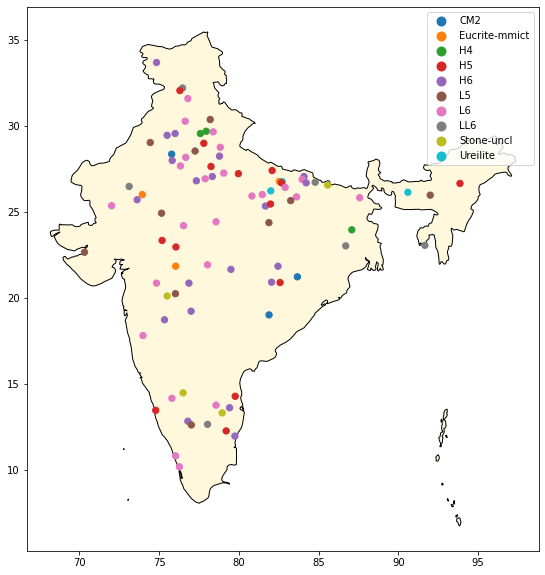

```python
# plot them on the map, colourcoded

base = india.plot(color='cornsilk', edgecolor='black')
india_count10.plot(ax=base, marker='o', column='recclass', legend = True, markersize=40);
```

```python
# there are a lot of points in the same spot, making it difficult to see where the CM2 type is
# to visualize the rare meteorite type better, we select and plot only this type

india_CM2 = india_count.loc[india_count['recclass'] == 'CM2']
india_CM2.head()
```

|  | index_left | pop_est | continent | country | iso_a3 | gdp_md_est | name | id | nametype | recclass | mass | fall | year | reclat | reclong | GeoLocation | geometry |
| --- | --- | --- | --- | --- | --- | --- | --- | --- | --- | --- | --- | --- | --- | --- | --- | --- | --- |
| 285 | 98.0 | 1.281936e+09 | Asia | India | IND | 8721000.0 | Erakot | 10042 | Valid | CM2 | 113.0 | Fell | 1940 | 19.03333 | 81.89167 | (19.033330, 81.891670) | POINT (81.89167 19.03333) |
| 364 | 98.0 | 1.281936e+09 | Asia | India | IND | 8721000.0 | Haripura | 11829 | Valid | CM2 | 315.0 | Fell | 1921 | 28.38333 | 75.78333 | (28.383330, 75.783330) | POINT (75.78333 28.38333) |
| 681 | 98.0 | 1.281936e+09 | Asia | India | IND | 8721000.0 | Nawapali | 16927 | Valid | CM2 | 105.0 | Fell | 1890 | 21.25000 | 83.66667 | (21.250000, 83.666670) | POINT (83.66667 21.25000) |

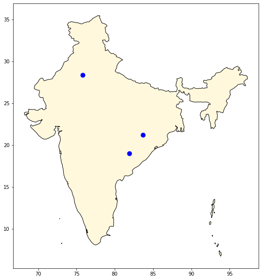

```python
# plot CM2 on map

base = india.plot(color='cornsilk', edgecolor='black')
india_CM2.plot(ax=base, marker='o', color = 'blue', markersize=80)
```

## 7. Conclusions

This visual analysis gave me a clear overview of the numbers of found meteorites per country, and which countries are promising locations for a meteorite-hunting expedition.